# Exploring the Relationship between Smoking, Alcohol Consumption, and Demographic Factors: A Survey-Based Analysis

Devpriyadharsan Balan Saravanan - 22250355

### 1. What percentage of the population smokes and how does this vary by age?

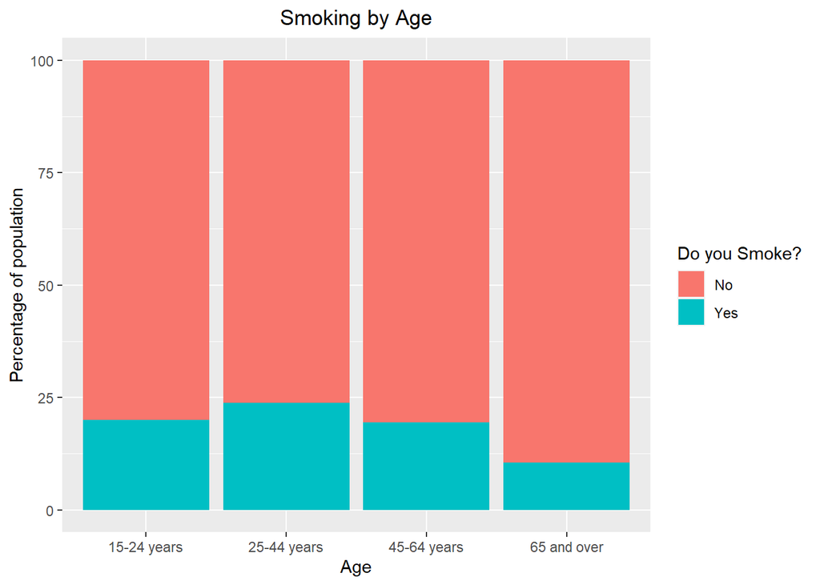

This output provides insights into the prevalence of smoking among different age groups.

- For the age group **15-24 years**, the percentage of non-smokers is approximately 80.06% and the percentage of smokers is 19.94%.
- For the age group **25-44 years**, the percentage of non-smokers is approximately 76.17% and the percentage of smokers is 23.83%.
- For the age group **45-64 years**, the percentage of non-smokers is approximately 80.58% and the percentage of smokers is 19.42%.
- For the age group **65 and over**, the percentage of non-smokers is approximately 89.44% and the percentage of smokers is 10.56%.

The highest percentage of smokers is observed in the age group “25-44 years” with approximately 23.83% of individuals being smokers. This age group has a higher smoking prevalence compared to other age groups.

The age group “65 and over” has the lowest smoking prevalence, with only approximately 10.56% of individuals being smokers. This age group has the lowest percentage of smokers among all the age groups analyzed.

The age groups “15-24 years” and “45-64 years” show relatively similar smoking prevalence, with approximately 19.94% and 19.42% of individuals being smokers, respectively.

Overall, the analysis indicates that smoking prevalence varies across different age groups. These findings highlight the importance of targeted smoking prevention and cessation efforts, particularly among the younger age groups where smoking rates are relatively higher.

**Calculating relative risk and an odds ratio for 25-44 year olds compared to 65 +**

- relative risk = 0.2383/0.1056 = 2.25
- odds for 25-44 = 0.2383/(1-0.2383) = 0.31
- odds for 65+ = 0.1056/(1-0.1056) = 0.12
- odds ratio = 0.31/0.12 = 2.58

The relative risk compares the risk of smoking between the two age groups. A relative risk of 2.25 means that individuals in the 25-44 age group have a 2.25 times higher risk of smoking compared to individuals aged 65 and above. This indicates that the younger age group has a significantly higher likelihood of being smokers compared to the older age group.

The odds ratio compares the odds of smoking between the two age groups. An odds ratio of 2.58 means that the odds of smoking in the 25-44 age group are 2.58 times higher than the odds of smoking in the 65+ age group. This suggests that individuals in the younger age group are more likely to smoke than individuals in the older age group.

This finding highlights the importance of targeted interventions and prevention efforts to reduce smoking prevalence among younger individuals. It suggests that specific strategies and policies should be implemented to address the higher smoking rates observed in the 25-44 age group. These measures could include education, awareness campaigns, smoking cessation programs, and policies aimed at reducing tobacco accessibility and promoting healthier behaviors.

#### Chi-squared test

```
##
##  Pearson's Chi-squared test
##
## data:  q1
## X-squared = 135.88, df = 3, p-value < 2.2e-16
```

### 2. What percentage of the population smokes and how does this vary by gender?

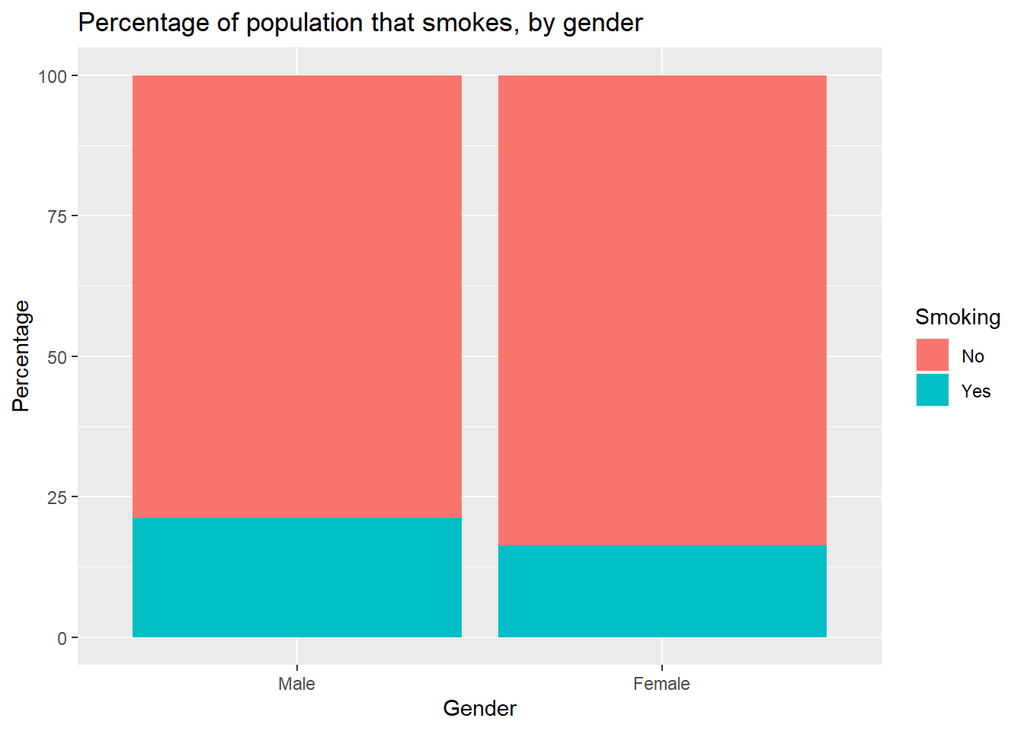

The output provides a clear breakdown of the percentage of population that smokes, categorized by gender.

1. For males, 21.19% of them reported smoking, while the majority (78.81%) do not smoke. On the other hand, among females, only 16.38% reported smoking, while the majority (83.62%) do not smoke.
2. This indicates that both males and females have a higher percentage of non-smokers compared to smokers. However, there is a slightly higher prevalence of smoking among males compared to females.

This information can be useful for public health interventions and targeted smoking cessation programs, taking into account the gender-specific patterns of smoking behavior.

**calculating relative risk and an odds ratio for males compared to females**

- relative risk = 0.2119/0.1637 = 1.29
- odds for males = 0.2119/(1-0.2119) = 0.26 yes/no
- odds for females = 0.1637/(1-0.1637) = 0.19
- odds ratio = 0.31/0.12 = 1.36

The relative risk compares the risk of smoking between males and females. A relative risk of 1.29 means that males have a 1.29 times higher risk of smoking compared to females. This suggests that males are slightly more likely to be smokers than females.

The odds ratio compares the odds of smoking between males and females. An odds ratio of 1.36 means that the odds of smoking in males are 1.36 times higher than the odds of smoking in females. This indicates that males have slightly higher odds of being smokers compared to females.

It’s important to note that while the relative risk and odds ratio indicate a small difference in smoking prevalence between males and females, the effect size is relatively modest. Other factors such as socio-cultural influences, socioeconomic status, and individual behaviors can also play a significant role in smoking patterns.

Efforts to reduce smoking rates should consider the gender-specific factors that contribute to smoking behavior. Tailored interventions and targeted strategies may be beneficial to address the higher smoking rates observed among males. These may include gender-specific smoking cessation programs, awareness campaigns, and policy measures to reduce smoking prevalence and promote healthier lifestyles for all genders.

#### Chi-squared test

```
##
##  Pearson's Chi-squared test with Yates' continuity correction
##
## data:  q2
## X-squared = 28.9, df = 1, p-value = 7.622e-08
```

### 3. What percentage of the population smokes and how does this vary by socioeconomic status?

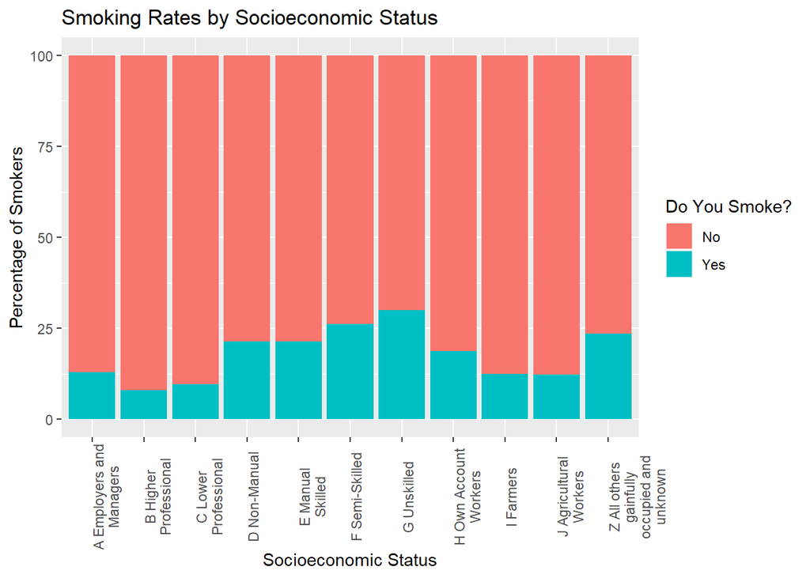

The data reveals interesting patterns in smoking rates across different socioeconomic groups.

1. Smoking Rates: The data reveals varying smoking rates among different socioeconomic groups. For example, the “A Employers and Managers” group has a smoking rate of 13.01%, while the “B Higher Professional” group has a smoking rate of 7.95%. On the other hand, the “G Unskilled” group has a higher smoking rate of 29.91%. These differences indicate that smoking behavior differs across socioeconomic categories.
2. Socioeconomic Disparities: The data highlights notable disparities in smoking rates across socioeconomic groups. Some groups, such as “A Employers and Managers” and “B Higher Professional,” have relatively lower smoking rates, while groups like “G Unskilled” have higher smoking rates. These disparities suggest that socioeconomic factors play a role in smoking behavior.
3. Socioeconomic Influence: The data supports the hypothesis that socioeconomic status influences smoking rates. Higher socioeconomic groups tend to have lower smoking rates, potentially due to factors like better access to healthcare, higher awareness of health risks, and stronger social norms against smoking. In contrast, lower socioeconomic groups face more challenges in quitting smoking, such as limited resources for smoking cessation programs and higher exposure to smoking triggers.

In conclusion, the analysis of the data underscores the association between smoking rates and socioeconomic status. The findings indicate that smoking rates significantly vary across different socioeconomic groups, suggesting a link between socioeconomic factors and smoking behavior. These findings highlight the importance of considering socioeconomic disparities when implementing smoking cessation programs, tobacco control policies, and public health campaigns.

Targeted interventions should focus on addressing the specific needs and challenges faced by different socioeconomic groups. Efforts should be made to provide accessible and affordable smoking cessation resources, education on the health risks of smoking, and supportive environments to help individuals quit smoking, particularly in higher-risk groups with higher smoking rates.

By understanding the relationship between smoking and socioeconomic status, policymakers, healthcare professionals, and public health advocates can develop comprehensive strategies to reduce smoking prevalence, promote healthier behaviors, and improve overall population health.

The odds ratio compares the odds of smoking between Unskilled workers and Employers/Managers. An odds ratio of 2.87 means that the odds of smoking in Unskilled workers are 2.87 times higher than the odds of smoking in Employers/Managers. This indicates that Unskilled workers have significantly higher odds of being smokers compared to Employers/Managers.

These findings highlight the importance of considering occupational factors when developing tobacco control and smoking cessation strategies. Unskilled workers may face unique challenges and higher levels of stress, which can contribute to higher smoking rates. Tailored interventions, workplace-based smoking cessation programs, and policies promoting smoke-free environments may be beneficial for reducing smoking prevalence among Unskilled workers.

It is important to address health disparities and provide support and resources for individuals in different occupational categories. By understanding the specific needs and challenges faced by Unskilled workers, targeted interventions can be developed to help reduce smoking rates and improve overall health outcomes.

#### Chi-squared test

```
##
##  Pearson's Chi-squared test
##
## data:  q3
## X-squared = 197.15, df = 10, p-value < 2.2e-16
```

### 4. What are the observed variations in smoking rates across different local health offices (LHOs) in various counties?

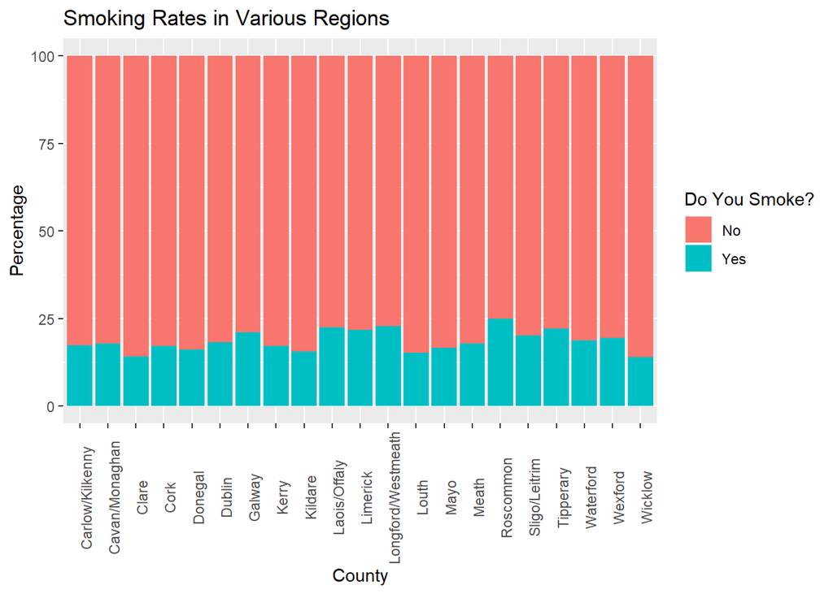

The provided table displays the smoking rates in different local health offices (LHOs) across various counties. It includes the LHO names (lho), the percentage of smokers or non-smokers (perc), and the smoking status (q6: “Yes” indicates smokers, “No” indicates non-smokers).

- Starting with Carlow/Kilkenny, it is observed that 82.68% of individuals in this area are non-smokers, while the remaining 17.32% are smokers. Similarly, in Cavan/Monaghan, the majority of individuals (82.18%) do not smoke, with 17.82% being smokers. In Clare, the trend continues with 85.87% of individuals being non-smokers and 14.13% being smokers.
- Moving on to Cork, the data reveals that 82.90% of individuals in this region do not smoke, while 17.10% are smokers. Likewise, in Donegal, the majority of individuals (83.86%) are non-smokers, whereas 16.14% are smokers. The trend continues in Dublin, where 81.84% of individuals are non-smokers, and the remaining 18.16% smoke.
- In Galway, the data indicates that 78.89% of individuals do not smoke, while 21.11% are smokers. Similarly, in Kerry, the majority (82.89%) do not smoke, while 17.11% are smokers. The data for Kildare/West Wicklow shows that 84.46% of individuals do not smoke, and 15.54% are smokers.
- Moving on to Laois/Offaly, it is observed that 77.55% of individuals in this area do not smoke, whereas 22.45% are smokers. In Limerick, the trend continues with 78.16% of individuals being non-smokers, and 21.84% being smokers. The data for Longford/Westmeath indicates that 77.27% of individuals do not smoke, while 22.73% are smokers.
- In Louth, the majority of individuals (84.73%) are non-smokers, whereas 15.27% are smokers. In Mayo, a similar trend is observed, with 83.29% of individuals being non-smokers and 16.71% being smokers. The data for Meath shows that 82.19% of individuals do not smoke, while 17.81% are smokers.
- Moving on to Roscommon, it is seen that 75.12% of individuals do not smoke, and 24.88% are smokers. In Sligo/Leitrim/West Cavan, the majority (79.91%) do not smoke, while 20.09% are smokers. The data for Tipperary indicates that 77.96% of individuals do not smoke, whereas 22.04% are smokers.
- In Waterford, the trend continues with 81.21% of individuals being non-smokers, and 18.79% being smokers. Similarly, in Wexford, the majority (80.60%) do not smoke, while 19.40% are smokers. Finally, in Wicklow, 85.95% of individuals do not smoke, whereas 14.05% are smokers.

Conclusion:

By understanding the smoking patterns at the regional level, public health authorities can develop targeted strategies to reduce smoking prevalence in specific areas. These may include awareness campaigns, smoking cessation programs, and policy interventions aimed at creating smoke-free environments and providing support for individuals to quit smoking. Additionally, the data can inform resource allocation and help prioritize interventions based on the identified areas with higher smoking rates.

It is important to note that smoking rates are influenced by various factors, including socioeconomic conditions, cultural norms, access to healthcare, and tobacco control policies. Therefore, a comprehensive approach that addresses these underlying determinants is crucial in achieving sustained reductions in smoking prevalence.

**calculating relative risk and an odds ratio for Roscommon compared to Meath**

- relative risk = 0.2488/0.1781 = 1.39
- odds for Roscommon = 0.2488/(1-0.2488) = 0.33
- odds for Meath = 0.1781/(1-0.1781) = 0.21
- odds ratio = 0.33/0.21 = 1.57

The relative risk of smoking in Roscommon compared to Meath is 1.39. This suggests that individuals in Roscommon are 1.39 times more likely to smoke compared to individuals in Meath.

The odds ratio for smoking in Roscommon compared to Meath is 1.57. This indicates that the odds of smoking in Roscommon are 1.57 times higher than the odds of smoking in Meath.

These findings highlight regional disparities in smoking prevalence and suggest that there may be regional-specific factors influencing smoking behavior. Understanding the underlying determinants of higher smoking rates in Roscommon can help inform targeted interventions and policies to reduce smoking prevalence in that region. Such interventions may include community-based smoking cessation programs, increased access to tobacco cessation resources, and targeted public health campaigns.

It is important to address these regional disparities in smoking rates to promote equitable health outcomes and reduce the burden of smoking-related diseases. By identifying and targeting the unique challenges and risk factors in regions with higher smoking prevalence, effective strategies can be implemented to reduce smoking rates and improve the overall health of the population.

#### Chi-squared test

```
##
##  Pearson's Chi-squared test
##
## data:  q4
## X-squared = 32.915, df = 20, p-value = 0.03447
```

### 5. How do smoking rates vary based on the country of birth?

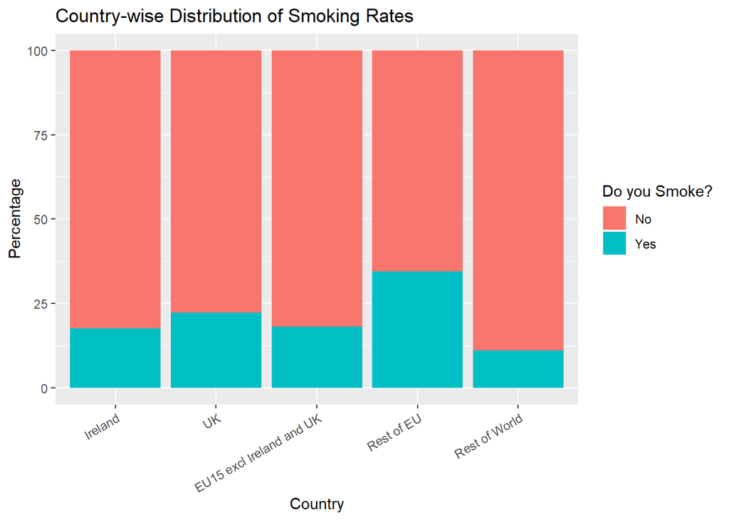

The graph displays the smoking rates based on the country of birth.

1. Smoking Rates by Country of Birth: The table presents the smoking rates among individuals based on their country of birth. For example, among individuals born in Ireland, 17.66% are smokers, while among those born in the UK, the smoking rate is 22.25%. These rates differ based on the country of birth, indicating variations in smoking behaviors among different populations.
2. Variation in Smoking Rates: The data highlights significant differences in smoking rates based on the country of birth. For instance, individuals born in the Rest of the World have a lower smoking rate of 11.05%, while those born in the Rest of EU have a higher rate of 34.46%. These disparities suggest that cultural and demographic factors associated with the country of birth may influence smoking behaviors.
3. Comparison by Country of Birth: The table allows for a comparison of smoking rates among individuals from different countries. For example, individuals born in Ireland have a relatively balanced smoking rate, with 17.66% being smokers. In contrast, individuals born in the Rest of the World exhibit a significantly lower smoking rate of 11.05%.

Understanding these variations can help in developing targeted interventions and tailored smoking cessation programs for specific populations. It emphasizes the importance of considering cultural and demographic factors associated with the country of birth when addressing smoking behaviors.

**calculating relative risk and an odds ratio for Ireland compared to Rest of EU**

- relative risk = 0.1765/0.3446 = 0.51
- odds for Ireland = 0.1765/(1-0.1765) = 0.21
- odds for Rest of EU = 0.3446/(1-0.3446) = 0.52
- odds ratio = 0.43/0.15 = 0.41

The relative risk compares the risk of smoking between Ireland and the Rest of the EU. A relative risk of 0.51 suggests that individuals in Ireland have a 0.51 times lower risk of smoking compared to individuals in the Rest of the EU. This indicates that smoking prevalence is lower in Ireland compared to the Rest of the EU.

The odds ratio compares the odds of smoking between Ireland and the Rest of the EU. An odds ratio of 0.41 means that the odds of smoking in Ireland are 0.41 times lower than the odds of smoking in the Rest of the EU. This further supports the finding that individuals in Ireland have lower odds of being smokers compared to individuals in the Rest of the EU.

These findings reflect the effectiveness of tobacco control measures and public health campaigns in Ireland, which have contributed to a lower prevalence of smoking. The implementation of comprehensive tobacco control policies, including smoking bans, increased taxation on tobacco products, and public health education, has played a crucial role in reducing smoking rates in Ireland.

Continued efforts and investments in comprehensive tobacco control strategies are necessary to maintain and further reduce smoking rates, not only in Ireland but also in the Rest of the EU. By prioritizing evidence-based interventions and adopting best practices, public health authorities can contribute to improving population health and reducing the burden of smoking-related diseases.

### 6. What is the distribution of health conditions among smokers and non-smokers across different age classes and genders?

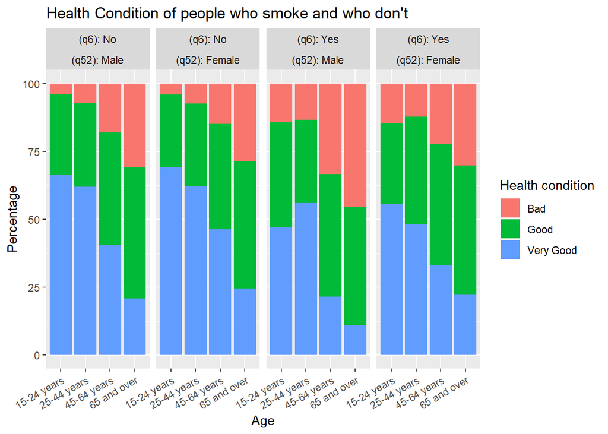

The provided data shows the distribution of individuals across different age groups (ageclass) and their smoking status (q6). The data also includes information about gender (GENDER), self-reported health status (spq1), and percentage of individuals in each category.

1. **Age Group: 15-24 years:**
   1. **Male:**
   - Non-smokers: 66.27% of non-smoking males reported very good health conditions.
   - Smokers: Among male smokers, 47.14% reported very good health conditions. This suggests that a significant proportion of male smokers still maintain good overall health.
   2. **Female:**
   - Non-smokers: 69.14% of non-smoking females reported very good health conditions.
   - Smokers: Among female smokers, 55.56% reported very good health conditions. This indicates that a considerable proportion of female smokers still enjoy good overall health.
2. **Age Group: 25-44 years:**
   1. **Male:**
   - Non-smokers: 62.03% of non-smoking males reported very good health conditions.
   - Smokers: Among male smokers, 55.89% reported very good health conditions. This suggests that a considerable proportion of male smokers still maintain good overall health.
   2. **Female:**
   - Non-smokers: 62.08% of non-smoking females reported very good health conditions.
   - Smokers: Among female smokers, 48.17% reported very good health conditions. This indicates that a significant proportion of female smokers still enjoy good overall health.
3. **Age Group: 45-64 years:**
   1. **Male:**
   - Non-smokers: 40.51% of non-smoking males reported very good health conditions.
   - Smokers: Among male smokers, 45.27% reported good health conditions. This suggests that a significant proportion of male smokers still maintain relatively good overall health.
   2. **Female:**
   - Non-smokers: 46.31% of non-smoking females reported very good health conditions.
   - Smokers: Among female smokers, 44.86% reported good health conditions. This indicates that a considerable proportion of female smokers still enjoy relatively good overall health.
4. **Age Group: 65 and over:**
   1. **Male:**
   - Non-smokers: 30.84% of non-smoking males reported bad health conditions.
   - Smokers: Among male smokers, 43.70% reported good health conditions. This suggests that a considerable proportion of male smokers still maintain relatively good overall health.
   2. **Female:**
   - Non-smokers: 28.76% of non-smoking females reported bad health conditions.
   - Smokers: Among female smokers, 47.47% reported good health conditions. This indicates that a significant proportion of female smokers still enjoys relatively good overall health.

   **Conclusion:**
- In the 15-24 age group, both male and female non-smokers generally maintain very good health. Among smokers, a significant proportion still maintains good overall health, although the percentage is slightly lower than non-smokers.
- In the 25-44 age group, both male and female non-smokers generally maintain very good health. Among smokers, a considerable proportion still maintains good overall health, although the percentage is lower than non-smokers.
- In the 45-64 age group, both male and female non-smokers generally maintain good overall health. Among smokers, a significant proportion still maintains relatively good health conditions.
- In the 65 and over age group, both non-smoking males and females exhibit a higher prevalence of health issues. However, among smokers, a considerable proportion still maintains relatively good health conditions.

Overall, the analysis shows that while smoking can have negative health effects, a significant proportion of individuals across different age groups and genders still maintain good or very good health despite being smokers. It’s important to note that quitting smoking is generally associated with better health outcomes. These findings highlight the need for smoking cessation efforts and personalized health considerations when assessing the relationship between smoking and health outcomes.

### 7. In the last 12 months, how often you have a smoking habit, and do you have private health insurance?

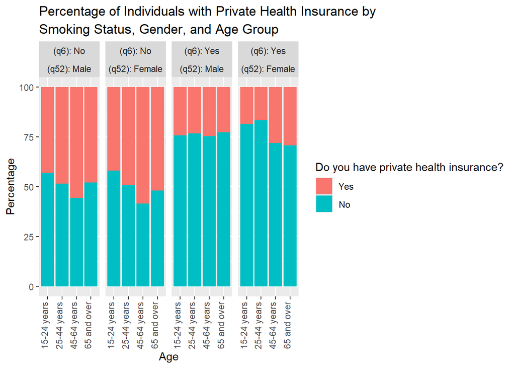

Let’s analyze the relationship between smoking status, gender, age group, and the possession of private health insurance:

1. **Smoking Status: No**
   1. **Male:**
   - Age Group: 15-24 years: Among non-smoking males, 56.86% do not have private health insurance, while 43.14% have private health insurance.
   - Age Group: 25-44 years: Among non-smoking males, 51.62% do not have private health insurance, while 48.38% have private health insurance.
   - Age Group: 45-64 years: Among non-smoking males, 44.44% do not have private health insurance, while 55.56% have private health insurance.
   - Age Group: 65 and over: Among non-smoking males, 52.10% do not have private health insurance, while 47.90% have private health insurance.
   2. **Female:**
   - Age Group: 15-24 years: Among non-smoking females, 58.02% do not have private health insurance, while 41.98% have private health insurance.
   - Age Group: 25-44 years: Among non-smoking females, 50.81% do not have private health insurance, while 49.19% have private health insurance.
   - Age Group: 45-64 years: Among non-smoking females, 41.63% do not have private health insurance, while 58.37% have private health insurance.
   - Age Group: 65 and over: Among non-smoking females, 48.13% do not have private health insurance, while 51.87% have private health insurance.
2. **Smoking Status: Yes**
   1. **Male:**
   - Age Group: 15-24 years: Among smoking males, 75.71% do not have private health insurance, while 24.29% have private health insurance.
   - Age Group: 25-44 years: Among smoking males, 76.77% do not have private health insurance, while 23.23% have private health insurance.
   - Age Group: 45-64 years: Among smoking males, 75.31% do not have private health insurance, while 24.69% have private health insurance.
   - Age Group: 65 and over: Among smoking males, 77.31% do not have private health insurance, while 22.69% have private health insurance.
   2. **Female:**
   - Age Group: 15-24 years: Among smoking females, 81.48% do not have private health insurance, while 18.52% have private health insurance.
   - Age Group: 25-44 years: Among smoking females, 83.39% do not have private health insurance, while 16.61% have private health insurance.
   - Age Group: 45-64 years: Among smoking females, 72.02% do not have private health insurance, while 27.98% have private health insurance.
   - Age Group: 65 and over: Among smoking females, 70.71% do not have private health insurance, while 29.29% have private health insurance.

### 8. What is the relationship between the prevalence of smoking among the surveyed individuals based on their age group and their status as the Chief Income Earner in their household?

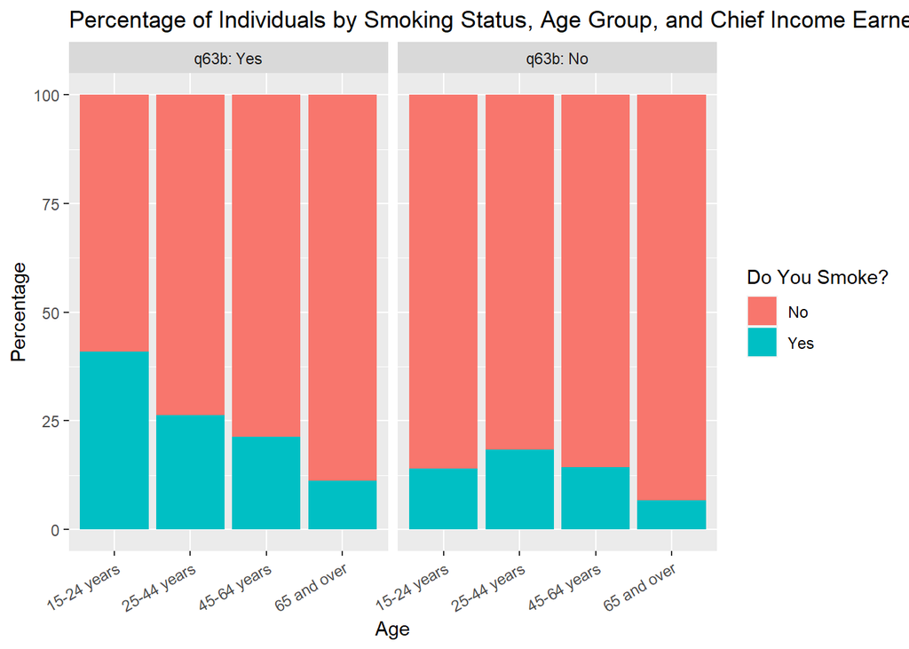

Based on the breakdown of being the Chief Income Earner in the household (q63b) by age class (AGECLASS) and smoking status (q6):

It’s important to note that being the Chief Income Earner can depend on various factors such as education, occupation, and household dynamics. Further analysis and consideration of these factors would be necessary to draw more definitive conclusions.

### 9. What percentage of the population consumes alcohol and how does this vary by age?

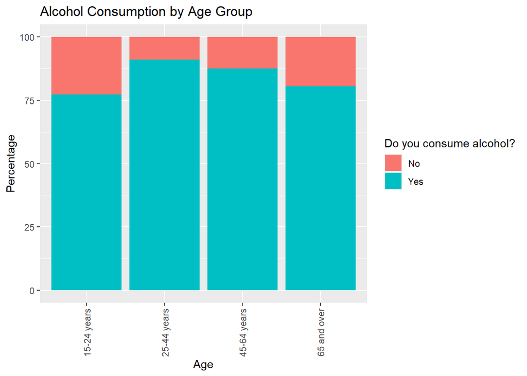

1. **Age Group “15-24 years”**: The majority of individuals in this age group (77.33%) consume alcohol, while a smaller percentage (22.67%) do not consume alcohol.
2. **Age Group “25-44 years”**: A significant majority of individuals in this age group (91.07%) consume alcohol, with only a small percentage (8.93%) not consuming alcohol.
3. **Age Group “45-64 years”**: A high percentage of individuals in this age group (87.50%) consume alcohol, while a relatively smaller percentage (12.50%) do not consume alcohol.
4. **Age Group “65 and over”**: The majority of individuals in this age group (80.48%) consume alcohol, while a smaller percentage (19.52%) do not consume alcohol.

**calculating relative risk and an odds ratio (Alcohol consumption) for 25-44 year olds compared to 65 +**

- relative risk = 0.9107/0.8048 = 1.13
- odds for 25-44 = 0.9107/(1-0.9107) = 10.19
- odds for 65+ = 0.8048/(1-0.8048) = 4.12
- odds ratio = 0.31/0.12 = 2.47

The relative risk of 1.13 indicates that individuals in the 25-44 age group have a 1.13 times higher risk of consuming alcohol compared to those in the 65 and over age group. This suggests a slightly higher prevalence of alcohol consumption in the younger age group.

The odds ratio of 2.47 implies that the odds of alcohol consumption are 2.47 times higher in the 25-44 age group compared to the 65 and over age group. This indicates a significant difference in alcohol consumption patterns between the two age groups, with a higher likelihood of alcohol consumption in the younger age group.

These findings align with general trends in alcohol consumption, where younger individuals tend to have higher rates of alcohol use. It is important to address alcohol consumption behaviors, particularly among younger age groups, through education, awareness campaigns, and targeted interventions to promote responsible and healthy alcohol consumption habits. Additionally, efforts to prevent alcohol-related harm should also be focused on older age groups, as a significant proportion of individuals in these age groups still consume alcohol.

#### Chi-squared test

```
##
##  Pearson's Chi-squared test
##
## data:  q5
## X-squared = 148.89, df = 3, p-value < 2.2e-16
```

### 10. What percentage of the population consumes alcohol and how does this vary by gender?

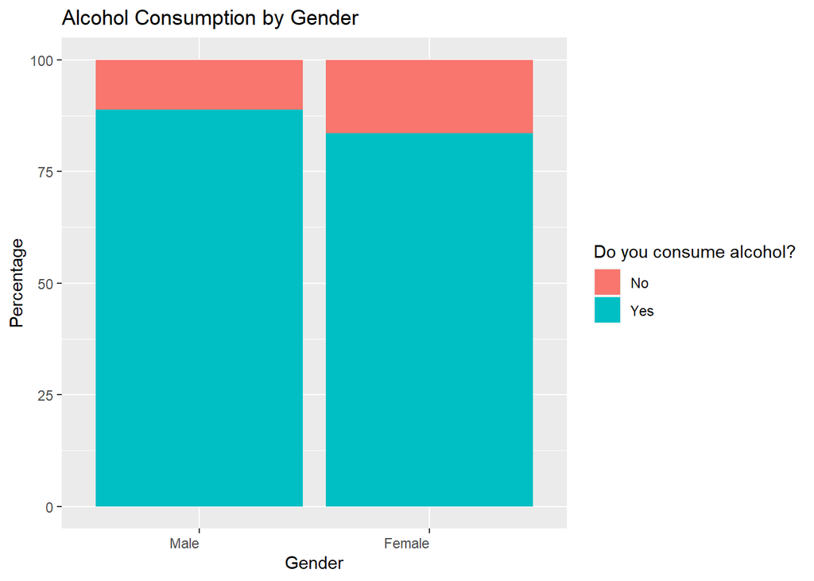

Males: Among males, a significant majority (88.88%) consume alcohol, while a relatively smaller percentage (11.12%) do not consume alcohol.

Females: Among females, the majority (83.60%) consume alcohol, while a smaller percentage (16.40%) do not consume alcohol.

Based on the provided data, it appears that both males and females have a substantial proportion of individuals who consume alcohol.

**calculating relative risk and an odds ratio (Alcohol consumption) for males compared to females**

- relative risk = 0.8888/0.8359 = 1.06
- odds for males = 0.8888/(1-0.8888) = 7.99
- odds for females = 0.8359/(1-0.8359) = 5.09
- odds ratio = 7.99/5.09 = 1.56

The calculated relative risk of 1.06 suggests that males have a 1.06 times higher risk of consuming alcohol compared to females. This indicates a slightly higher prevalence of alcohol consumption among males, although the difference is not substantial.

The odds ratio is 1.56, indicating that males have 1.56 times higher odds of consuming alcohol compared to females. This suggests a moderate association between gender and alcohol consumption, with males having higher odds of being alcohol consumers compared to females.

Based on the data, it can be concluded that there is a moderate association between gender and alcohol consumption. Males have a slightly higher prevalence and odds of consuming alcohol compared to females. The findings emphasize the need for comprehensive alcohol-related interventions and education for both genders to promote responsible alcohol consumption and address potential health risks associated with excessive alcohol use.

#### Chi-squared test

```
##
##  Pearson's Chi-squared test with Yates' continuity correction
##
## data:  q6
## X-squared = 43.597, df = 1, p-value = 4.035e-11
```

### 11. What percentage of the population consumes alcohol, and how does this vary by socioeconomic status?

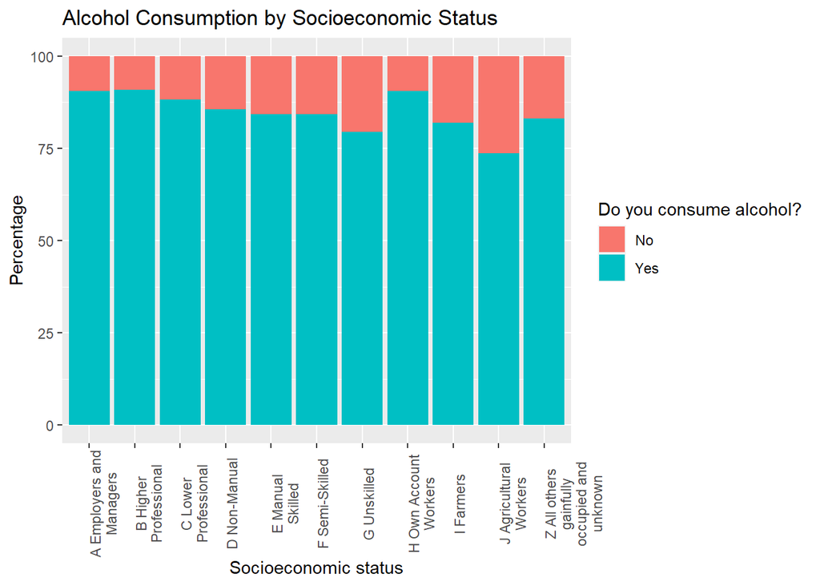

These findings suggest that there are variations in alcohol consumption patterns across different social economic groups. Factors such as occupation, income, and social status may influence these patterns.

The odds ratio is 3.43, indicating that Employers and Managers have 3.43 times higher odds of consuming alcohol compared to Agricultural Workers. This suggests a moderate association between occupational group and alcohol consumption, with Employers and Managers having higher odds of being alcohol consumers compared to Agricultural Workers.

Based on the data, it can be concluded that there is a moderate association between occupational group and alcohol consumption. These findings highlight the importance of considering occupational factors when addressing alcohol consumption patterns and implementing workplace wellness programs that promote responsible drinking behavior. It is essential to provide resources, support, and education on alcohol consumption within different occupational settings to ensure the well-being and safety of all individuals.

#### Chi-squared test

```
##
##  Pearson's Chi-squared test
##
## data:  q7
## X-squared = 73.225, df = 10, p-value = 1.053e-11
```

### 12. What are the patterns of alcohol consumption across different local health offices (LHOs) within each county?

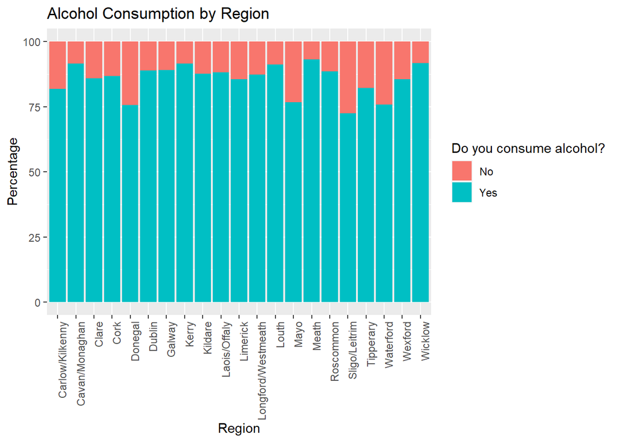

Carlow/Kilkenny, Cavan/Monaghan, Clare, and Cork are regions where a significant majority of individuals consume alcohol. The percentages of drinkers in these regions are 81.89%, 91.58%, 85.87%, and 86.74%, respectively. This suggests a prevalent drinking culture in these areas, with a higher prevalence of alcohol consumption among the population.

Examining the regional variations in alcohol consumption is essential for public health officials and policymakers. It allows them to better understand the unique challenges and needs of each region regarding alcohol-related issues. By recognizing areas with higher rates of alcohol consumption, targeted interventions and educational campaigns can be developed to address harmful drinking patterns and promote responsible alcohol use.

Moreover, the regions with a higher proportion of non-drinkers, such as Donegal and Sligo/Leitrim/West Cavan, may offer opportunities to explore factors contributing to lower alcohol consumption rates. Understanding the cultural, socioeconomic, and environmental influences that contribute to these patterns can help inform interventions aimed at reducing alcohol-related harms and promoting healthier behaviors.

In conclusion, the findings indicate significant regional variations in alcohol consumption across Ireland. The results can guide policymakers, public health officials, and community leaders in tailoring strategies and interventions to address alcohol-related challenges specific to each region. By promoting responsible drinking behaviors and fostering a better understanding of alcohol’s impact on health and well-being, efforts can be made to create a safer and healthier drinking culture throughout the country.

**calculating relative risk and an odds ratio (Alcohol consumption) for Galway compared to Limerick**

- relative risk = 0.8912/0.8544 = 1.04
- odds for Galway = 0.8912/(1-0.8912) = 8.19
- odds for Limerick = 0.8544/(1-0.8544) = 5.86
- odds ratio = 8.19/5.86 = 1.39

The relative risk compares the likelihood of alcohol consumption between two groups. In this case, the relative risk of Galway compared to Limerick is calculated by dividing the percentage of drinkers in Galway (89.12%) by the percentage of drinkers in Limerick (85.44%). The result is 1.04, indicating that individuals in Galway have a slightly higher risk of alcohol consumption compared to those in Limerick.

The odds for alcohol consumption in Galway can be calculated by dividing the percentage of drinkers (89.12%) by the percentage of non-drinkers (100% - 89.12% = 10.88%). This gives us an odds value of 8.19, meaning that individuals in Galway are approximately 8.19 times more likely to consume alcohol than to not consume it. Similarly, the odds for alcohol consumption in Limerick can be calculated using the percentage of drinkers (85.44%) and the percentage of non-drinkers (100% - 85.44% = 14.56%). The odds value for Limerick is approximately 5.86, indicating that individuals in Limerick are about 5.86 times more likely to consume alcohol than to not consume it.

The odds ratio compares the odds of an event occurring between two groups. In this case, the odds ratio for Galway compared to Limerick is calculated by dividing the odds for Galway (8.19) by the odds for Limerick (5.86). The result is approximately 1.39, suggesting that individuals in Galway have 1.39 times higher odds of consuming alcohol compared to those in Limerick.

These calculations provide insights into the differences in alcohol consumption between Galway and Limerick. While Galway has a slightly higher relative risk and higher odds of alcohol consumption compared to Limerick, the differences are relatively small.

#### Chi-squared test

```
##
##  Pearson's Chi-squared test
##
## data:  q8
## X-squared = 175.75, df = 20, p-value < 2.2e-16
```

### 13. How does alcohol consumption vary among the surveyed individuals based on their country of birth?

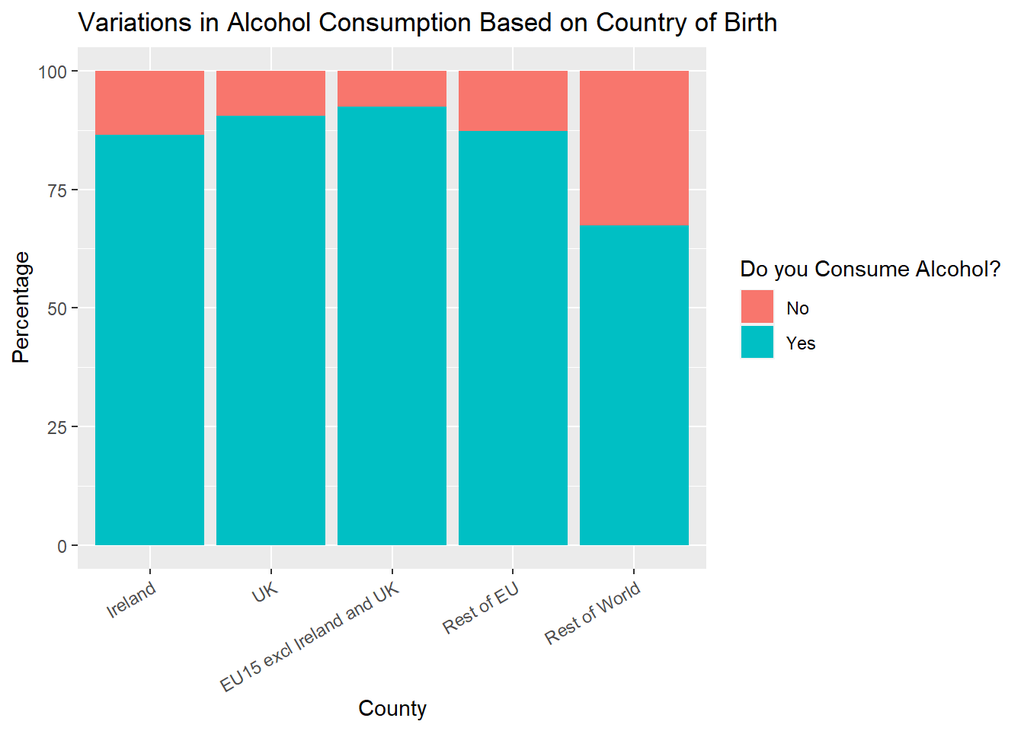

The graph displays the alcohol consumption rates based on the country of birth.

Understanding these variations in alcohol consumption rates can inform the development of targeted interventions and tailored alcohol awareness programs for specific populations. It underscores the significance of considering cultural and demographic factors associated with the country of birth when addressing alcohol consumption behaviors.

**calculating relative risk and an odds ratio (Alcohol Consumption) for Ireland compared to Rest of EU**

- relative risk = 0.8653/0.8728 = 0.99
- odds for Ireland = 0.8653/(1-0.8653) = 6.42
- odds for Rest of EU = 0.8728/(1-0.8728) = 6.86
- odds ratio = 6.42/6.86 = 0.93

The relative risk compares the risk of alcohol consumption between Ireland and the Rest of the EU. A relative risk of 0.99 suggests that individuals in Ireland have a similar risk of alcohol consumption compared to individuals in the Rest of the EU. This indicates that alcohol consumption rates are comparable between Ireland and the Rest of the EU.

The odds ratio compares the odds of alcohol consumption between Ireland and the Rest of the EU. An odds ratio of 0.93 means that the odds of alcohol consumption in Ireland are 0.93 times lower than the odds of alcohol consumption in the Rest of the EU. This suggests that individuals in Ireland have slightly lower odds of being alcohol consumers compared to individuals in the Rest of the EU.

These findings indicate that there is no significant difference in alcohol consumption rates between Ireland and the Rest of the EU. The prevalence of alcohol consumption seems to be similar in both populations.

Understanding the factors influencing alcohol consumption behaviors is essential for public health interventions and policies aimed at promoting responsible drinking and reducing alcohol-related harms. Continued monitoring and evaluation of alcohol consumption trends can inform targeted interventions and strategies to address alcohol misuse and promote healthier behaviors.

### 14. How does the distribution of alcohol consumption vary among different age classes and genders in relation to health conditions?

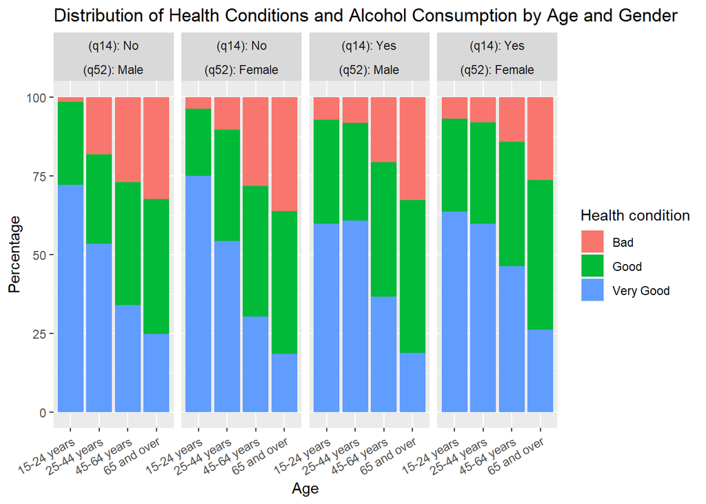

Overall, the analysis shows that while alcohol consumption can lead to some negative health effects, a considerable proportion of individuals across different age groups still maintain good or very good health despite drinking. It’s important to note that moderation and individual factors play a significant role in the overall impact of alcohol on health. These findings highlight the need for responsible alcohol consumption and personalized health considerations when assessing the relationship between alcohol and health outcomes.

### 15. In the last 12 months, how often have you consumed alcoholic beverages and have a private health insurance?

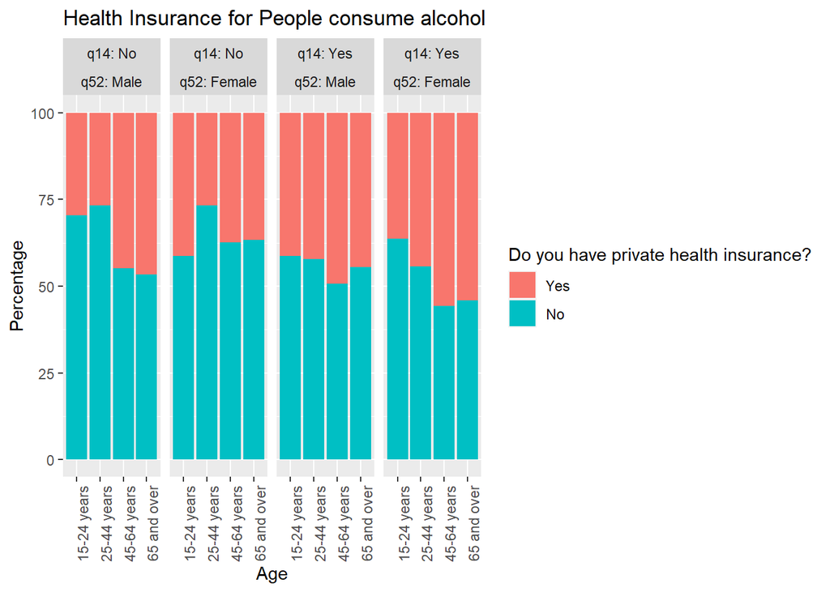

### 16. What is the relationship between the prevalence of consumption of alcohol among the surveyed individuals based on their age group and their status as the Chief Income Earner in their household?

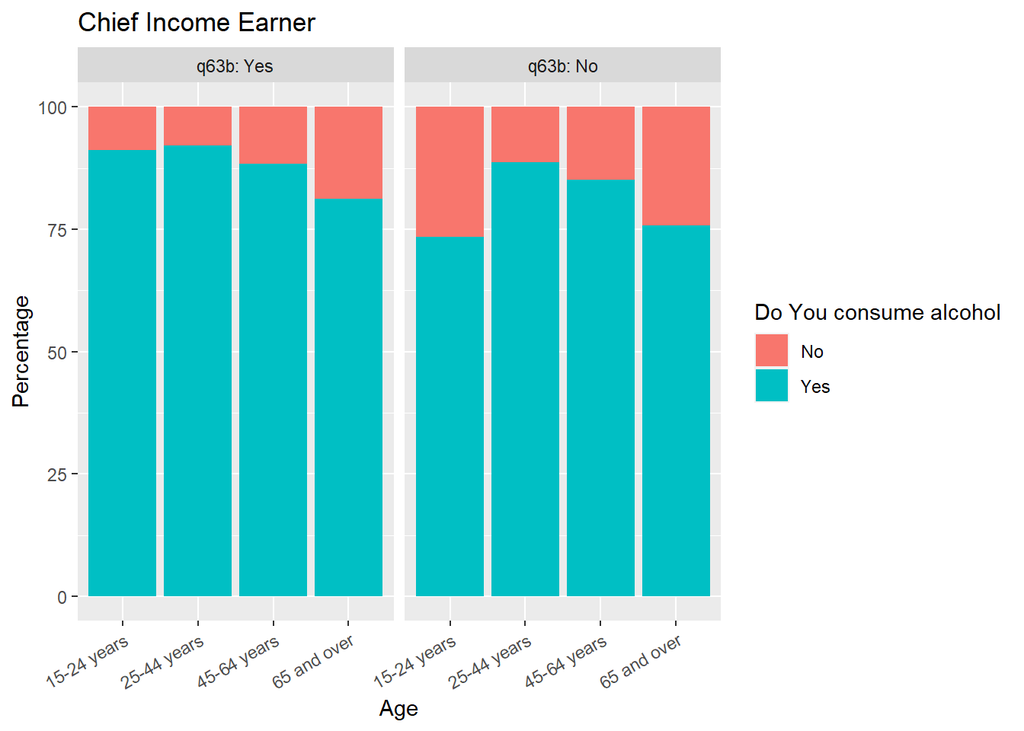

Based on the breakdown of being the Chief Income Earner in the household (q63b) by age class (AGECLASS) and alcohol consumption (q14), let’s provide a detailed explanation and conclusion:

1. **Age Class: 15-24 years**:
   - Among individuals aged 15-24 years, a significant majority (91.24%) of those who are the Chief Income Earner consume alcohol.
   - The count for Chief Income Earners in this age group who consume alcohol is 125, while those who do not consume alcohol have a count of 12.
   - Among those who are not the Chief Income Earner, there is a higher count of individuals who consume alcohol (356) compared to those who do not (129).
2. **Age Class: 25-44 years**:
   - In the age group of 25-44 years, the majority (92.15%) of those who are the Chief Income Earner consume alcohol.
   - The count for Chief Income Earners in this age group who consume alcohol is 1597, while those who do not consume alcohol have a count of 136.
   - Among those who are not the Chief Income Earner, there is a higher count of individuals who consume alcohol (688) compared to those who do not (88).
3. **Age Class: 45-64 years**:
   - Among individuals aged 45-64 years, the majority (88.39%) of those who are the Chief Income Earner consume alcohol.
   - The count for Chief Income Earners in this age group who consume alcohol is 1622, while those who do not consume alcohol have a count of 213.
   - Among those who are not the Chief Income Earner, there is a higher count of individuals who consume alcohol (568) compared to those who do not (100).
4. **Age Class: 65 and over**:
   - In the age group of 65 and over, the majority (81.28%) of those who are the Chief Income Earner consume alcohol.
   - The count for Chief Income Earners in this age group who consume alcohol is 1433, while those who do not consume alcohol have a count of 330.
   - Among those who are not the Chief Income Earner, there is a higher count of individuals who consume alcohol (229) compared to those who do not (73).

Overall, the data shows that across all age classes, a higher percentage of individuals who are the Chief Income Earner in their household consume alcohol compared to those who do not. This trend is consistent across different age groups.

It’s important to note that alcohol consumption can have various implications on individuals’ health, finances, and overall well-being. Further analysis and consideration of these factors would be necessary to draw more comprehensive conclusions.

### 17. How does folic acid consumption vary across different regions in terms of percentages?

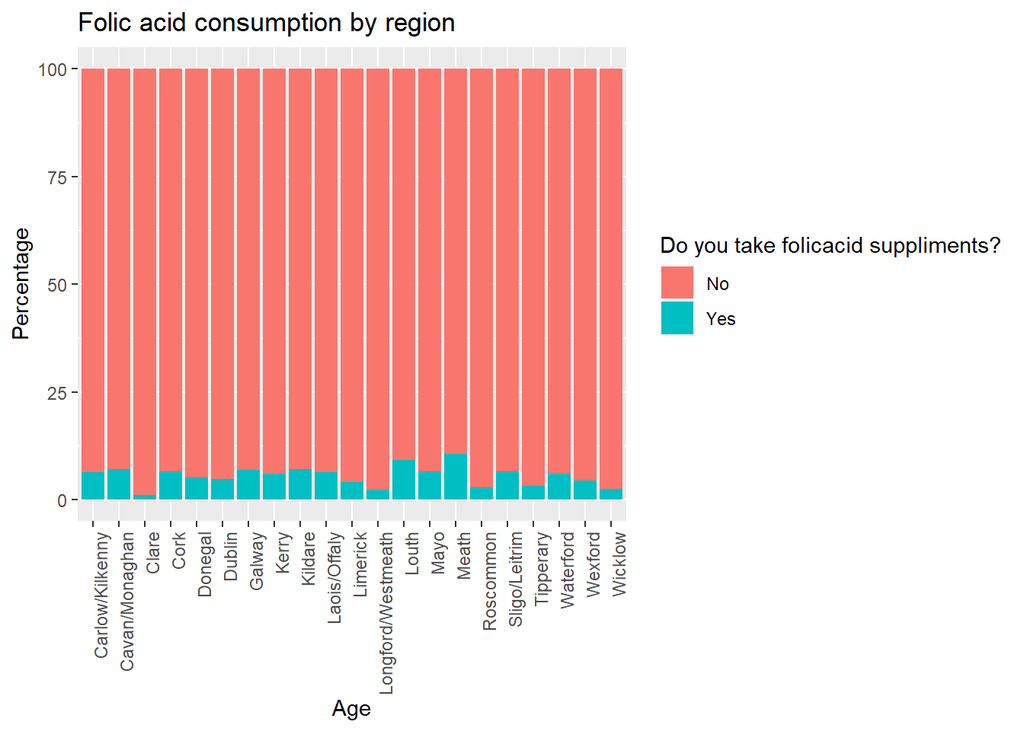

In conclusion, the analysis of folic acid consumption by region provides valuable insights into the prevalence and regional variations of folic acid supplementation. This information can guide public health strategies and interventions aimed at improving folic acid awareness, accessibility, and uptake, ultimately contributing to better maternal and child health outcomes.

**calculating relative risk and an odds ratio (Folic acid consumption) for Meath compared to Galway**

- relative risk = 0.1052/0.0682 = 1.54
- odds for Meath = 0.1052/(1-0.1052) = 0.11
- odds for Galway = 0.0682/(1-0.0682) = 0.07
- odds ratio = 0.11/0.07 = 1.57

Based on the data, the relative risk of folic acid consumption in Meath compared to Galway is 1.54. This indicates that individuals in Meath have a 1.54 times higher risk of consuming folic acid supplements compared to individuals in Galway.

The odds for folic acid consumption in Meath are 0.11, meaning that the odds of individuals in Meath taking folic acid supplements are 0.11 times the odds of not taking them. In comparison, the odds for folic acid consumption in Galway are 0.07, indicating that the odds of individuals in Galway taking folic acid supplements are 0.07 times the odds of not taking them.

The odds ratio for Meath compared to Galway is 1.57. This means that individuals in Meath have 1.57 times higher odds of consuming folic acid supplements compared to individuals in Galway.

### 18. How do individuals rate their own health in general, and are there differences between genders and lhos?

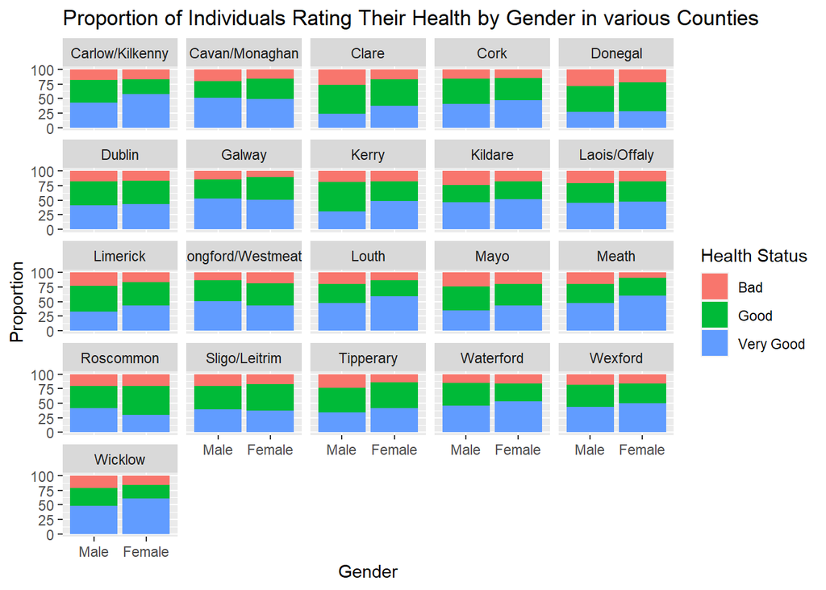

Based on the breakdown of self-perceived health (spq1) by local health office (lho), gender (q52), and the corresponding percentages, the detailed explanation is as follows:

**Local Health Office: Carlow/Kilkenny**

- Among males, 18.37% perceive their health as “Bad,” 38.78% perceive it as “Good,” and 42.86% perceive it as “Very Good.”
- Among females, 16.67% perceive their health as “Bad,” 25.64% perceive it as “Good,” and 57.69% perceive it as “Very Good.”

**Local Health Office: Cavan/Monaghan**

- Among males, 20% perceive their health as “Bad,” 28.42% perceive it as “Good,” and 51.58% perceive it as “Very Good.”
- Among females, 15.89% perceive their health as “Bad,” 34.58% perceive it as “Good,” and 49.53% perceive it as “Very Good.”

**Local Health Office: Clare**

- Among males, 26.44% perceive their health as “Bad,” 49.43% perceive it as “Good,” and 24.14% perceive it as “Very Good.”
- Among females, 17.53% perceive their health as “Bad,” 45.36% perceive it as “Good,” and 37.11% perceive it as “Very Good.”

**Local Health Office: Cork**

- Among males, 15.68% perceive their health as “Bad,” 43.94% perceive it as “Good,” and 40.38% perceive it as “Very Good.”
- Among females, 14.52% perceive their health as “Bad,” 38.60% perceive it as “Good,” and 46.88% perceive it as “Very Good.”

**Local Health Office: Donegal**

- Among males, 28.43% perceive their health as “Bad,” 44.16% perceive it as “Good,” and 27.41% perceive it as “Very Good.”
- Among females, 22.02% perceive their health as “Bad,” 49.54% perceive it as “Good,” and 28.44% perceive it as “Very Good.”

**Local Health Office: Dublin**

- Among males, 17.49% perceive their health as “Bad,” 41.98% perceive it as “Good,” and 40.52% perceive it as “Very Good.”
- Among females, 16.29% perceive their health as “Bad,” 40.99% perceive it as “Good,” and 42.72% perceive it as “Very Good.”

**Local Health Office: Galway**

- Among males, 14.98% perceive their health as “Bad,” 32.60% perceive it as “Good,” and 52.42% perceive it as “Very Good.”
- Among females, 9.92% perceive their health as “Bad,” 39.26% perceive it as “Good,” and 50.83% perceive it as “Very Good.”

**Local Health Office: Kerry**

- Among males, 18.84% perceive their health as “Bad,” 50.72% perceive it as “Good,” and 30.43% perceive it as “Very Good.”
- Among females, 18.07% perceive their health as “Bad,” 33.73% perceive it as “Good,” and 48.19% perceive it as “Very Good.”

**Local Health Office: Kildare/West Wicklow**

- Among males, 23.85% perceive their health as “Bad,” 30.28% perceive it as “Good,” and 45.87% perceive it as “Very Good.”
- Among females, 18.31% perceive their health as “Bad,” 30.28% perceive it as “Good,” and 51.41% perceive it as “Very Good.”

**Local Health Office: Laois/Offaly**

- Among males, 20.93% perceive their health as “Bad,” 33.33% perceive it as “Good,” and 45.74% perceive it as “Very Good.”
- Among females, 17.58% perceive their health as “Bad,” 35.15% perceive it as “Good,” and 47.27% perceive it as “Very Good.”

**Local Health Office: Limerick**

- Among males, 22.54% perceive their health as “Bad,” 45.07% perceive it as “Good,” and 32.39% perceive it as “Very Good.”
- Among females, 16.09% perceive their health as “Bad,” 40.80% perceive it as “Good,” and 43.10% perceive it as “Very Good.”

**Local Health Office: Longford/Westmeath**

- Among males, 13.82% perceive their health as “Bad,” 35.53% perceive it as “Good,” and 50.66% perceive it as “Very Good.”
- Among females, 18.59% perceive their health as “Bad,” 38.46% perceive it as “Good,” and 42.95% perceive it as “Very Good.”

**Local Health Office: Louth**

- Among males, 19.30% perceive their health as “Bad,” 33.33% perceive it as “Good,” and 47.37% perceive it as “Very Good.”
- Among females, 12.84% perceive their health as “Bad,” 28.38% perceive it as “Good,” and 58.78% perceive it as “Very Good.”

**Local Health Office: Mayo**

- Among males, 23.42% perceive their health as “Bad,” 41.14% perceive it as “Good,” and 35.44% perceive it as “Very Good.”
- Among females, 19.49% perceive their health as “Bad,” 36.92% perceive it as “Good,” and 43.59% perceive it as “Very Good.”

**Local Health Office: Meath**

- Among males, 20.00% perceive their health as “Bad,” 32.63% perceive it as “Good,” and 47.37% perceive it as “Very Good.”
- Among females, 9.21% perceive their health as “Bad,” 30.26% perceive it as “Good,” and 60.53% perceive it as “Very Good.”

**Local Health Office: Roscommon**

- Among males, 20.75% perceive their health as “Bad,” 37.74% perceive it as “Good,” and 41.51% perceive it as “Very Good.”
- Among females, 20.72% perceive their health as “Bad,” 49.55% perceive it as “Good,” and 29.73% perceive it as “Very Good.”

**Local Health Office: Sligo/Leitrim/West Cavan**

- Among males, 20.37% perceive their health as “Bad,” 39.81% perceive it as “Good,” and 39.81% perceive it as “Very Good.”
- Among females, 17.36% perceive their health as “Bad,” 45.45% perceive it as “Good,” and 37.19% perceive it as “Very Good.”

**Local Health Office: Tipperary**

- Among males, 23.97% perceive their health as “Bad,” 41.78% perceive it as “Good,” and 34.25% perceive it as “Very Good.”
- Among females, 13.92% perceive their health as “Bad,” 44.94% perceive it as “Good,” and 41.14% perceive it as “Very Good.”

**Local Health Office: Waterford**

- Among males, 15.38% perceive their health as “Bad,” 38.46% perceive it as “Good,” and 46.15% perceive it as “Very Good.”
- Among females, 15.76% perceive their health as “Bad,” 31.52% perceive it as “Good,” and 52.73% perceive it as “Very Good.”

**Local Health Office: Wexford**

- Among males, 18.60% perceive their health as “Bad,” 37.21% perceive it as “Good,” and 44.19% perceive it as “Very Good.”
- Among females, 15.83% perceive their health as “Bad,” 33.81% perceive it as “Good,” and 50.36% perceive it as “Very Good.”

**Local Health Office: Wicklow**

- Among males, 21.30% perceive their health as “Bad,” 30.56% perceive it as “Good,” and 48.15% perceive it as “Very Good.”
- Among females, 15.67% perceive their health as “Bad,” 23.13% perceive it as “Good,” and 61.19% perceive it as “Very Good.”

### Models - Smoking

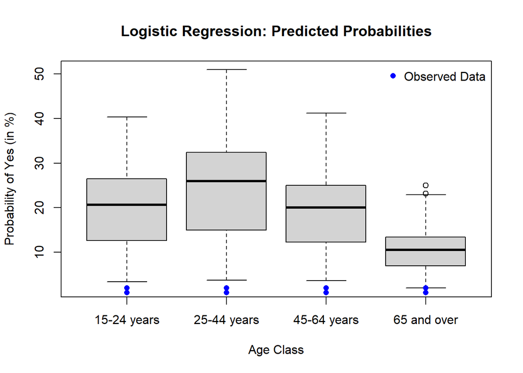

```
## [1] 0.01997226 0.45123102
```

#### Finding the Optimal Threshold for Logistic Regression using ROC Curve and Youden’s J Statistic

```
## [1] "Optimal Threshold: 0.2"
```

#### Logistic Regression - Accuracy

```
## Confusion Matrix and Statistics
##
##           Reference
## Prediction Yes  No
##        Yes 166 430
##        No  119 824
##
##                Accuracy : 0.6433
##                  95% CI : (0.6188, 0.6672)
##     No Information Rate : 0.8148
##     P-Value [Acc > NIR] : 1
##
##                   Kappa : 0.1685
##
##  Mcnemar's Test P-Value : <2e-16
##
##             Sensitivity : 0.5825
##             Specificity : 0.6571
##          Pos Pred Value : 0.2785
##          Neg Pred Value : 0.8738
##              Prevalence : 0.1852
##          Detection Rate : 0.1079
##    Detection Prevalence : 0.3873
##       Balanced Accuracy : 0.6198
##
##        'Positive' Class : Yes
##
```

```
## [1] "Accuracy: 64.33"
```

```
## [1] "Precision: 27.85"
```

```
## [1] "F1-Score: 37.68"
```

```
## # Hosmer-Lemeshow Goodness-of-Fit Test
##
##   Chi-squared: 5.023
##            df: 8
##       p-value: 0.755
```

```
## Analysis of Deviance Table
##
## Model: binomial, link: logit
##
## Response: q6_binary
##
## Terms added sequentially (first to last)
##
##
##          Df Deviance Resid. Df Resid. Dev  Pr(>Chi)
## NULL                      6158     5903.7
## ageclass  3  125.268      6155     5778.4 < 2.2e-16 ***
## q52       1   27.245      6154     5751.2 1.792e-07 ***
## key1     10  187.707      6144     5563.5 < 2.2e-16 ***
## lho      20   24.441      6124     5539.0  0.223669
## q120      2   12.711      6122     5526.3  0.001737 **
## ---
## Signif. codes:  0 '***' 0.001 '**' 0.01 '*' 0.05 '.' 0.1 ' ' 1
```

```
## [1] "AIC Value: 5600.31"
```

```
## [1] "BIC Value: 5849.16"
```

#### Naive bayes - Accuracy

```
## Confusion Matrix and Statistics
##
##           Reference
## Prediction Yes  No
##        Yes 163 434
##        No  122 820
##
##                Accuracy : 0.6387
##                  95% CI : (0.6142, 0.6628)
##     No Information Rate : 0.8148
##     P-Value [Acc > NIR] : 1
##
##                   Kappa : 0.1587
##
##  Mcnemar's Test P-Value : <2e-16
##
##             Sensitivity : 0.5719
##             Specificity : 0.6539
##          Pos Pred Value : 0.2730
##          Neg Pred Value : 0.8705
##              Prevalence : 0.1852
##          Detection Rate : 0.1059
##    Detection Prevalence : 0.3879
##       Balanced Accuracy : 0.6129
##
##        'Positive' Class : Yes
##
```

```
## [1] "Accuracy: 63.87"
```

```
## [1] "Precision: 27.3"
```

```
## [1] "F1-Score: 36.96"
```

### Models - Alcohol

#### Finding the Optimal Threshold for Logistic Regression using ROC Curve and Youden’s J Statistic

```
## [1] "Optimal Threshold: 0.82"
```

#### Logistic Regression - Accuracy

```
## Confusion Matrix and Statistics
##
##           Reference
## Prediction  Yes   No
##        Yes 1054  105
##        No   269  111
##
##                Accuracy : 0.757
##                  95% CI : (0.7348, 0.7782)
##     No Information Rate : 0.8596
##     P-Value [Acc > NIR] : 1
##
##                   Kappa : 0.2357
##
##  Mcnemar's Test P-Value : <2e-16
##
##             Sensitivity : 0.7967
##             Specificity : 0.5139
##          Pos Pred Value : 0.9094
##          Neg Pred Value : 0.2921
##              Prevalence : 0.8596
##          Detection Rate : 0.6849
##    Detection Prevalence : 0.7531
##       Balanced Accuracy : 0.6553
##
##        'Positive' Class : Yes
##
```

```
## [1] "Accuracy: 75.7"
```

```
## [1] "Precision: 90.94"
```

```
## [1] "F1-Score: 84.93"
```

```
## # Hosmer-Lemeshow Goodness-of-Fit Test
##
##   Chi-squared: 11.960
##            df:  8
##       p-value:  0.153
```

```
## Analysis of Deviance Table
##
## Model: binomial, link: logit
##
## Response: q14_binary
##
## Terms added sequentially (first to last)
##
##
##          Df Deviance Resid. Df Resid. Dev  Pr(>Chi)
## NULL                      6158     4998.3
## ageclass  3  107.101      6155     4891.2 < 2.2e-16 ***
## q52       1   40.990      6154     4850.2 1.530e-10 ***
## key1     10   35.551      6144     4814.6 0.0001005 ***
## lho      20  118.911      6124     4695.7 4.535e-16 ***
## q330_1    5    2.261      6119     4693.5 0.8119123
## q330_2    7    9.714      6112     4683.7 0.2053407
## ---
## Signif. codes:  0 '***' 0.001 '**' 0.01 '*' 0.05 '.' 0.1 ' ' 1
```

```
## [1] "AIC Value: 4777.75"
```

```
## [1] "BIC Value: 5093.86"
```

#### Naive bayes - Accuracy

```
## Confusion Matrix and Statistics
##
##           Reference
## Prediction  Yes   No
##        Yes 1043  106
##        No   280  110
##
##                Accuracy : 0.7492
##                  95% CI : (0.7267, 0.7707)
##     No Information Rate : 0.8596
##     P-Value [Acc > NIR] : 1
##
##                   Kappa : 0.2226
##
##  Mcnemar's Test P-Value : <2e-16
##
##             Sensitivity : 0.7884
##             Specificity : 0.5093
##          Pos Pred Value : 0.9077
##          Neg Pred Value : 0.2821
##              Prevalence : 0.8596
##          Detection Rate : 0.6777
##    Detection Prevalence : 0.7466
##       Balanced Accuracy : 0.6488
##
##        'Positive' Class : Yes
##
```

```
## [1] "Accuracy: 74.92"
```

```
## [1] "Precision: 90.77"
```

```
## [1] "F1-Score: 84.39"
```